# Greyhound Barrier Analysis

Plus a heap of tables and graphs

Rex Carruthers

## Motivation and Hypothesis

Contrived situation to act as a tutorial to explain how to use data exploration and modelling techniques in R.

The situation:

I’ve had plenty of lively pub conversations after a few beers, when it’s down to just the dogs left on the TAB, about which barrier is the best. There’s always one bloke who won’t stop going on about how the favourite in box one is the only smart bet and how I should’ve known better than to back a middle barrier dog, since they were always going to get taken out.

I hypothesis that barrier 1 is by far the best barrier to be given (especially at shorter race distances) but that advantage is included in the betting market price.

## Packages

```r
library(tidyverse)
library(performance)
library(sjPlot)
library(lme4)
library(broom.mixed)
```

## Data Import and Clean

I downloaded all of the [Betfair Historical](https://historicdata.betfair.com/#/home) greyhound data from the start of 2023 until the present (October 2025) and parsed the compressed json files into csv using their supplied python script that I updated (with a lot of help from Claude) to handle some of the data type errors I was getting. Here is the updated python script on my [Github](https://github.com/RexCarruthers/Website/blob/main/Greyhound/jtc3.py) if anyone is interested.

Below is a sample of the data they provide for each race:

```r
# Stops the tibble from hiding some of the columns
options(tibble.width = Inf)
# Import the csv
data <- read_csv("output_full3.csv")
# Data sample
data %>% select(event_date,track,market_name,selection_name,result,bsp) %>% head()
```

```
# A tibble: 6 × 6
  event_date          track         market_name selection_name     result    bsp
  <dttm>              <chr>         <chr>       <chr>              <chr>   <dbl>
1 2023-01-01 07:17:00 Murray Bridge R1 395m Mdn 1. Kahlua And Soda LOSER   27
2 2023-01-01 07:17:00 Murray Bridge R1 395m Mdn 2. Destini Fresco  LOSER  190
3 2023-01-01 07:17:00 Murray Bridge R1 395m Mdn 4. Stella Star     LOSER   48
4 2023-01-01 07:17:00 Murray Bridge R1 395m Mdn 5. Sticky Rice     LOSER   27.7
5 2023-01-01 07:17:00 Murray Bridge R1 395m Mdn 7. Paramount Ace   WINNER   3.39
6 2023-01-01 07:17:00 Murray Bridge R1 395m Mdn 8. Up There Rocco  LOSER    1.64
```

As Betfair is an exchange and not a bookmaker the odds don’t include an overround or vigorish portion that the bookmaker would make money. This simplifies the process of turning the odds into implied winning probabilities to just the inverse of the odds.

The is some data cleaning required to remove dogs that didn’t run and some additional quinella/head to head markets that we aren’t looking at for this study. I have also only used races where the market has matured and the sum of implied probabilities are close to 100% and there are 8 dogs in the race so all barriers are full. This removes occasions where dogs in inside barriers get clear runs due to having empty barriers next to them which we would have to create a feature for and reduces the amount of data to a more manageable level. The number below shows the number of races remaining after the cull.

```r
# Remove non running dogs and irrelevant markets
# Calculate implied probabilities and create a race id
data <- data %>%
  select(event_date:bsp) %>%
  filter(result != "REMOVED" & !is.na(bsp) & str_detect(market_name,"^R[:digit:]")) %>%
  group_by(event_date, track, market_name) %>%
  mutate(prob = 1/bsp, RID = cur_group_id())

# Create a df with total probability and runners per race
a <- data %>% group_by(RID) %>% summarise(mprob = sum(prob), runners = n())
# Filter out races where the market isn't set and only includes races with 8 dogs
RIDs <- a %>% filter(mprob < 1.02 & mprob > 0.98 & runners == 8) %>% select(RID) %>% pull()

length(RIDs)
```

```
[1] 56362
```

```r
# Only include the selected races
data <- data %>% filter(RID %in% RIDs)
```

The “market_name” and “selection_name” variables have multiple data points in each that we need to pull out to investigate our hypothesis. This can be done quite easily using regex and the stringr package as below. Once we have done that we can mutate all the created variables into the format that we will need for modelling.

Dogs also run at a lot of slightly different distances depending on the track. To simplify the modelling and to directly answer part of the hypothesis I’ve simplified the distance into 3 categories as per [GRV distinctions](https://www.grv.org.au/wp-content/uploads/2021/12/GRV-Grading-Guidelines-2022.pdf).

```r
# Extract data from columns using stringr and regex
data <- data %>% ungroup() %>%
  mutate(dist = as.numeric(str_extract(market_name, "(?<=[:blank:])[:digit:]*(?=m)")),
         grade = str_extract(market_name, "(?<=[:blank:])[:alnum:]*$"),
         rug = as.numeric(str_extract(selection_name, "^[:digit:]+")),
         name = str_sub(selection_name, start = (str_locate(selection_name, "[:blank:]")[1]+1), end = -1L))

# Categorical variables to factors and turn distance to a factor
data <- data %>%
  mutate(rug_f = as.factor(rug),
         name_f = as.factor(name),
         track_f = as.factor(track),
         dist_cat = as.factor(case_when(dist <= 423 ~ "Short",
                                        dist > 423 & dist <= 570 ~ "Sprint",
                                        dist > 570 ~ "Distance")))

# Turn WINNER/LOSER to 1/0
# Remove dogs with rugs > 8 as we don't know which barrier they are in
data <- data %>% mutate(res = ifelse(result == "WINNER", 1,0)) %>%
  filter(rug <= 8)
```

## Data Exploration

We can check how accurate the implied market odds are by creating a calibration curve comparing them to the actual results. We do this by binning the implied probabilities runs into 5% chunks and then calculating the actual win rate for that subset of dogs runs. I’ve also added a red dotted line showing what the perfect correlation between the actual and implied odds would be.

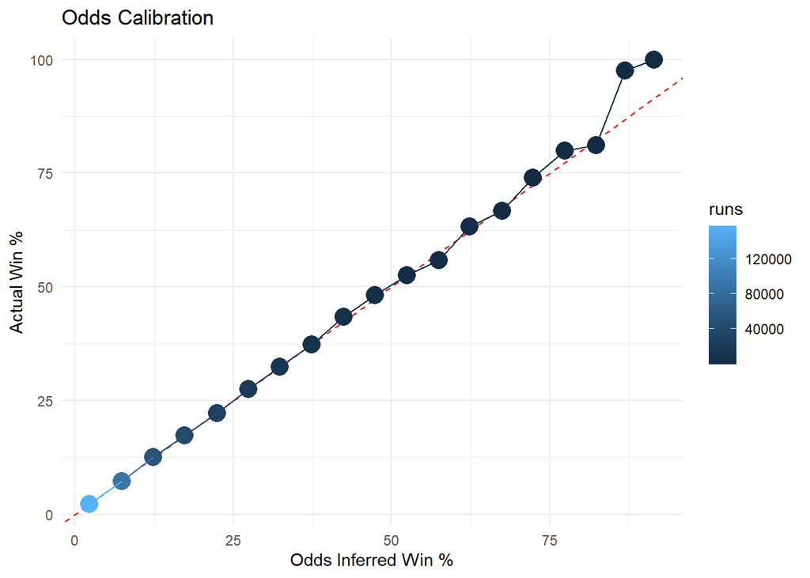

```r
# Create bins every 5% of implied probs
data$bin <- cut(data$prob, breaks = seq(from=0, to=1, by = 0.05),include.lowest=TRUE)

# Calc the actual winrate per bin
cc <- data %>%
  group_by(bin) %>%
  summarise(avgP = round(mean(prob)*100,2),
            runs = n(),
            wins = sum(result == "WINNER")) %>%
  mutate(apc = round((wins/runs)*100,2))

# Scatterplot
cc %>% ggplot(aes(x = avgP, y = apc, colour = runs)) +
  geom_abline(slope = 1, intercept = 0, colour = "red", linetype = "dashed") +
  geom_point(size = 5) +
  geom_line() +
  theme_minimal() +
  labs(title = "Odds Calibration",
       x = "Odds Inferred Win %",
       y = "Actual Win %")
```

To show this more clearly below is a distribution of the implied probabilities with the same bins as the plot above. This also shows how skewed the data is and because of this we will use the log of the probabilities when modelling to transform the variable into more of a normal distribution.

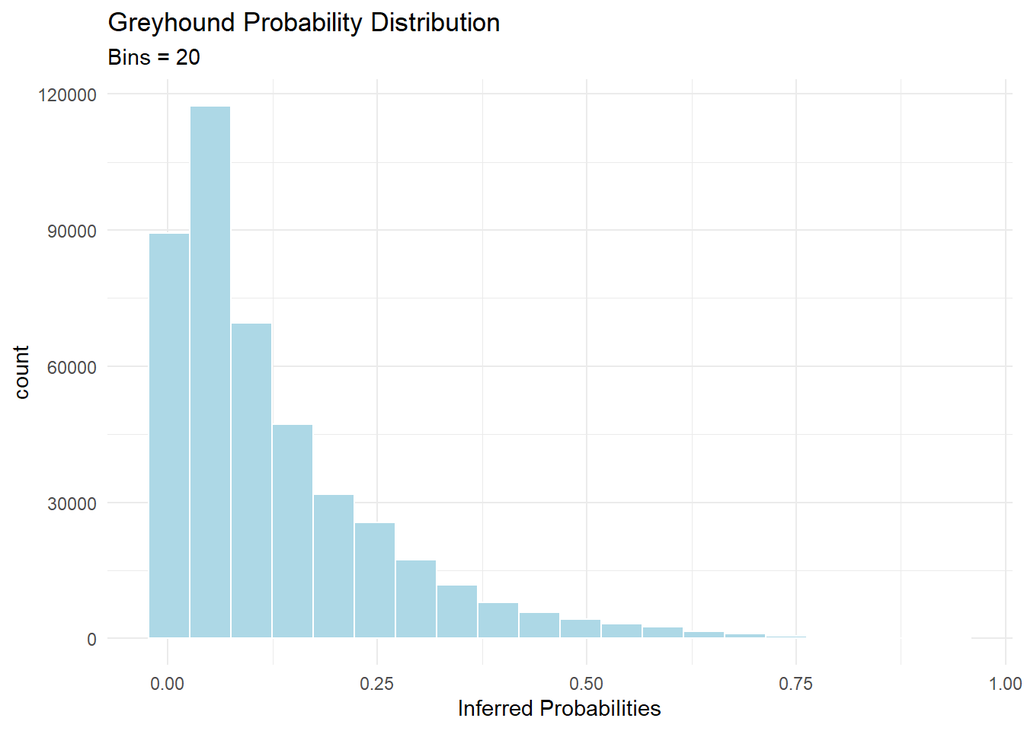

```r
# Implied Prob Distribution
data %>% ggplot(aes(x = prob)) +
  geom_histogram(colour = "white", fill = "lightblue", bins = 20) +
  theme_minimal() +
  labs(x = "Inferred Probabilities",
       title = "Greyhound Probability Distribution",
       subtitle = "Bins = 20")
```

Finally I calculated the win rate per barrier to answer the first part of the hypothesis. I have included a line at 100/8 = 12.5% to show where all the barriers would be if the result was uniformly distributed across barriers.

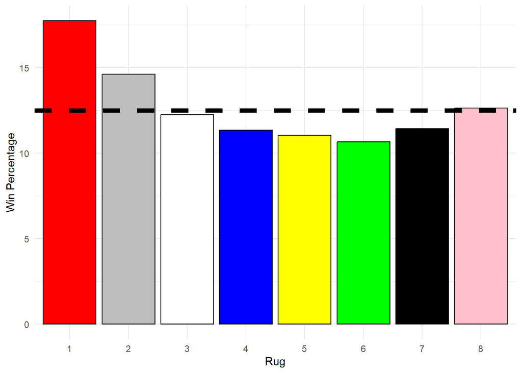

```r
# Plot winrate per barrier
data %>% filter(rug <= 8) %>%
  group_by(rug) %>%
  summarise(runs = n(),
            wins = sum(result == "WINNER"),
            avgP = round(mean(prob)*100,digits = 2)) %>%
  mutate(wpc = round((wins/runs)*100,digits = 2),
         rug = as.factor(rug)) %>%
  ggplot(aes(x = rug, y = wpc, fill = rug)) +
  geom_bar(stat = "identity", colour = "black") +
  geom_hline(yintercept = 12.5, linewidth = 2, linetype = "dashed") +
  scale_fill_manual(values = c("1" = "red",
                               "2" = "grey",
                               "3" = "white",
                               "4" = "blue",
                               "5" = "yellow",
                               "6" = "green",
                               "7" = "black",
                               "8" = "pink")) +
  theme_minimal() +
  labs(x = "Rug",
       y = "Win Percentage") +
  theme(legend.position = "")
```

You can see straight away that barrier 1 has a massive advantage winning over 17.5% of races with barrier 2 second with just under 15%. The percentage continues to decrease until you get to 7 and 8 who have slightly more room to run on the outside. This confirms the first half of our hypothesis, however, is this information included in the market odds?

If we group these by distance you can see that the barrier one advantage is similar across distance categories but largest in the middling “Sprint” category.

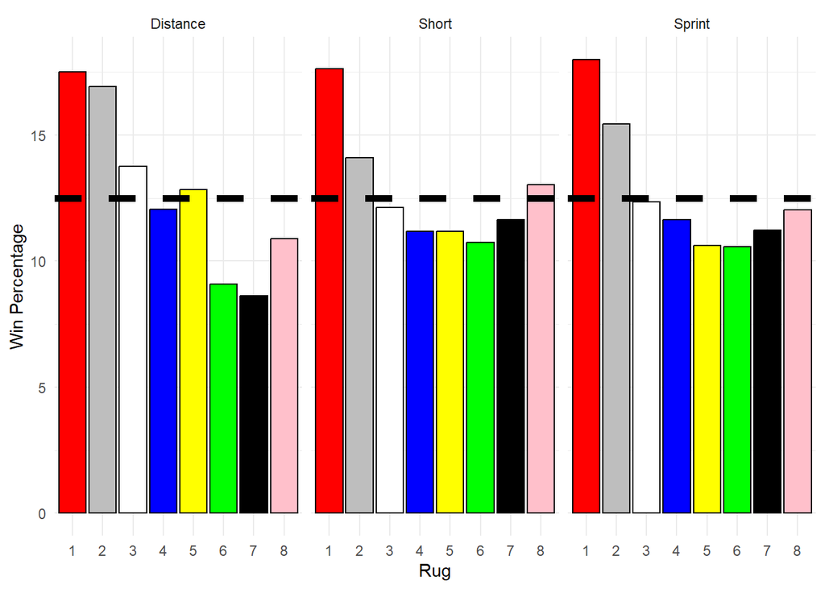

## Modelling

Since our outcome is binary (win/loss), I fitted binomial logistic regression models to test whether barrier information adds predictive value beyond market prices. Four models were constructed:

- **LM1:** Only rug/barrier
  - Establishes the baseline barrier effect observed in our exploratory analysis.
- **LM2:** Only the log of implied probabilities
  - Our benchmark model, if the market efficiently prices barrier advantage, this should capture all relevant information.
- **LM3:** Combining rug and log of implied probabilities
  - The critical test: if barrier remains significant after controlling for market odds, it suggests the market hasn’t fully incorporated barrier effects into prices.
- **LM4:** Interaction of rug and distance category
  - To investigate how the barrier effect changes with distance category

```r
# Only rug/barrier
lm1 <- glm(res ~ rug_f,
           data = data,
           family = binomial(link = "logit"))
# Only probability
lm2 <- glm(res ~ log(prob),
           data = data,
           family = binomial(link = "logit"))
# rug and probability
lm3 <- glm(res ~ rug_f + log(prob),
           data = data,
           family = binomial(link = "logit"))
# rug interaction with distance
lm4 <- glm(res ~ rug_f * dist_cat,
           data = data,
           family = binomial(link = "logit"))
```

## Analysis

See below the initial outputs of the first 3 models:

```r
# Models 1-3 - performance stats
tab_model(lm1,lm2,lm3, show.aic = T,
          dv.labels = c("Rug Only","Log Prob Only","Combined"))
```

|  | Rug Only |  |  | Log Prob Only |  |  | Combined |  |  |
| --- | --- | --- | --- | --- | --- | --- | --- | --- | --- |
| Predictors | Odds Ratios | CI | p | Odds Ratios | CI | p | Odds Ratios | CI | p |
| (Intercept) | 0.22 | 0.21 – 0.22 | **<0.001** | 2.04 | 1.99 – 2.09 | **<0.001** | 1.99 | 1.93 – 2.05 | **<0.001** |
| rug f [2] | 0.79 | 0.77 – 0.82 | **<0.001** |  |  |  | 1.03 | 1.00 – 1.07 | 0.084 |
| rug f [3] | 0.65 | 0.63 – 0.67 | **<0.001** |  |  |  | 1.05 | 1.01 – 1.09 | **0.006** |
| rug f [4] | 0.59 | 0.57 – 0.61 | **<0.001** |  |  |  | 1.01 | 0.98 – 1.05 | 0.455 |
| rug f [5] | 0.58 | 0.56 – 0.60 | **<0.001** |  |  |  | 1.06 | 1.02 – 1.10 | **0.002** |
| rug f [6] | 0.55 | 0.53 – 0.57 | **<0.001** |  |  |  | 1.05 | 1.01 – 1.09 | **0.013** |
| rug f [7] | 0.60 | 0.58 – 0.62 | **<0.001** |  |  |  | 1.08 | 1.04 – 1.12 | **<0.001** |
| rug f [8] | 0.67 | 0.65 – 0.69 | **<0.001** |  |  |  | 1.00 | 0.96 – 1.03 | 0.832 |
| prob [log] |  |  |  | 3.48 | 3.44 – 3.52 | **<0.001** | 3.50 | 3.45 – 3.54 | **<0.001** |
| Observations | 437633 |  |  | 437633 |  |  | 437633 |  |  |
| R<sup>2</sup> Tjur | 0.004 |  |  | 0.151 |  |  | 0.151 |  |  |
| AIC | 331677.991 |  |  | 272585.076 |  |  | 272568.108 |  |  |

The last model does show that rugs 3, 5, 6 and 7 are statistically significant which we will have to dive into more deeply.

We can pull the fixed effects (we haven’t utilised random effects in this study) using the broom.mixed package to show the results more clearly with a plot. We can check if the first model arrived at the same conclusion as us with the barrier win rates by plotting the odds ratio which compare the win probability to the first barrier and includes 95% confidence intervals.

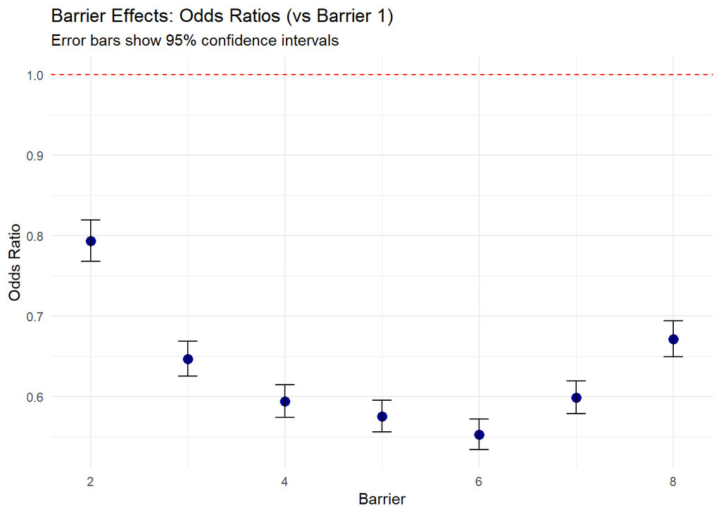

```r
# Pull out effects from the first model
fixed_effects <- tidy(lm1, effects = "fixed", conf.int = TRUE)

fixed_effects <- fixed_effects %>%
  mutate(
    odds_ratio = exp(estimate),
    or_lower = exp(conf.low),
    or_upper = exp(conf.high)
  )

#print(fixed_effects %>% select(term, odds_ratio, or_lower, or_upper, p.value))

barrier_effects <- fixed_effects %>%
  filter(grepl("rug_f", term)) %>%
  mutate(barrier = as.numeric(gsub("rug_f", "", term)))

ggplot(barrier_effects, aes(x = barrier, y = odds_ratio)) +
  geom_point(size = 3, color = "darkblue") +
  geom_errorbar(aes(ymin = or_lower, ymax = or_upper), width = 0.2) +
  geom_hline(yintercept = 1, linetype = "dashed", color = "red") +
  labs(
    title = "Barrier Effects: Odds Ratios (vs Barrier 1)",
    subtitle = "Error bars show 95% confidence intervals",
    x = "Barrier",
    y = "Odds Ratio"
  ) +
  theme_minimal()
```

However, when we include the implied probabilities (lm3) the plot tells a different story:

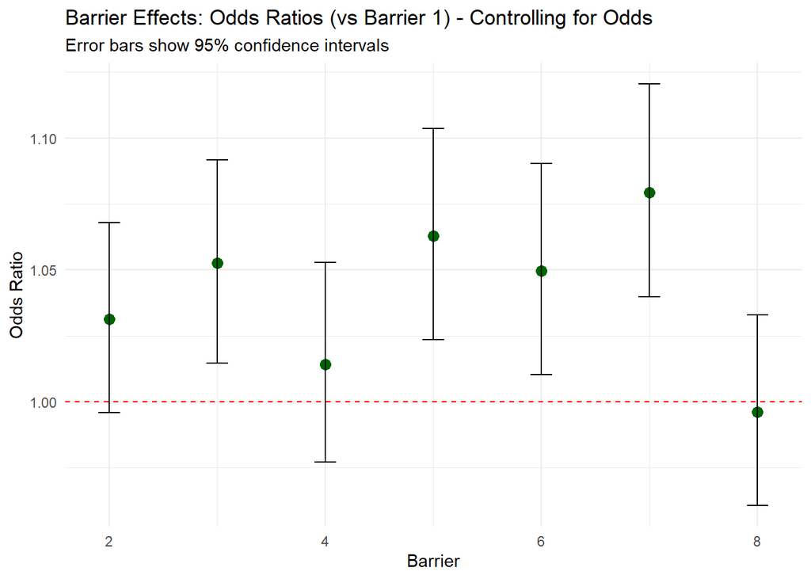

Now every barrier except for 8 has increased odds over barrier 1. This suggests that the market on average over values the dog in barrier 1 compared to the field with the error bars for barriers 3, 5, 6 and 7 entirely in the positive.

To check if this insight is statistically significant we can perform a chi-squared test to compare this model to the null hypothesis (lm2).

```r
anova(lm2, lm3, test = "Chisq")
```

```
Analysis of Deviance Table

Model 1: res ~ log(prob)
Model 2: res ~ rug_f + log(prob)
  Resid. Df Resid. Dev Df Deviance  Pr(>Chi)
1    437631     272581
2    437624     272550  7   30.968 6.302e-05 ***
---
Signif. codes:  0 '***' 0.001 '**' 0.01 '*' 0.05 '.' 0.1 ' ' 1
```

The test shows that the additional of the barrier/rug is statistically significant with a p value < 0.001.

If barrier advantage were already fully incorporated into market prices, then adding barrier information shouldn’t improve the ability to predict results beyond what the market probability already tells you. But it does improve the model significantly, which suggests the market prices don’t fully account for barrier effects and there’s predictive information in barrier position beyond what’s in the odds.

Finally, we can check our last model to see the impact of distance on barrier 1’s advantage. The below uses barrier 1 and the Distance category as references:

```r
# comparing rug and rug/distance
tab_model(lm1,lm4, show.aic = T,
          dv.labels = c("Rug Only","Rug*Distance"))
```

|  | Rug Only |  |  | Rug*Distance |  |  |
| --- | --- | --- | --- | --- | --- | --- |
| Predictors | Odds Ratios | CI | p | Odds Ratios | CI | p |
| (Intercept) | 0.22 | 0.21 – 0.22 | **<0.001** | 0.21 | 0.18 – 0.25 | **<0.001** |
| rug f [2] | 0.79 | 0.77 – 0.82 | **<0.001** | 0.96 | 0.78 – 1.18 | 0.703 |
| rug f [3] | 0.65 | 0.63 – 0.67 | **<0.001** | 0.75 | 0.60 – 0.94 | **0.011** |
| rug f [4] | 0.59 | 0.57 – 0.61 | **<0.001** | 0.65 | 0.51 – 0.81 | **<0.001** |
| rug f [5] | 0.58 | 0.56 – 0.60 | **<0.001** | 0.69 | 0.55 – 0.87 | **0.001** |
| rug f [6] | 0.55 | 0.53 – 0.57 | **<0.001** | 0.47 | 0.37 – 0.60 | **<0.001** |
| rug f [7] | 0.60 | 0.58 – 0.62 | **<0.001** | 0.44 | 0.35 – 0.57 | **<0.001** |
| rug f [8] | 0.67 | 0.65 – 0.69 | **<0.001** | 0.58 | 0.45 – 0.73 | **<0.001** |
| dist cat [Short] |  |  |  | 1.01 | 0.87 – 1.17 | 0.919 |
| dist cat [Sprint] |  |  |  | 1.03 | 0.89 – 1.20 | 0.682 |
| rug f [2] × dist cat [Short] |  |  |  | 0.80 | 0.65 – 0.99 | **0.041** |
| rug f [3] × dist cat [Short] |  |  |  | 0.86 | 0.69 – 1.08 | 0.183 |
| rug f [4] × dist cat [Short] |  |  |  | 0.91 | 0.72 – 1.15 | 0.429 |
| rug f [5] × dist cat [Short] |  |  |  | 0.85 | 0.68 – 1.07 | 0.161 |
| rug f [6] × dist cat [Short] |  |  |  | 1.20 | 0.93 – 1.54 | 0.161 |
| rug f [7] × dist cat [Short] |  |  |  | 1.38 | 1.08 – 1.79 | **0.012** |
| rug f [8] × dist cat [Short] |  |  |  | 1.22 | 0.96 – 1.54 | 0.107 |
| rug f [2] × dist cat [Sprint] |  |  |  | 0.87 | 0.70 – 1.08 | 0.201 |
| rug f [3] × dist cat [Sprint] |  |  |  | 0.86 | 0.68 – 1.08 | 0.181 |
| rug f [4] × dist cat [Sprint] |  |  |  | 0.93 | 0.74 – 1.18 | 0.553 |
| rug f [5] × dist cat [Sprint] |  |  |  | 0.78 | 0.62 – 0.99 | **0.037** |
| rug f [6] × dist cat [Sprint] |  |  |  | 1.14 | 0.89 – 1.48 | 0.298 |
| rug f [7] × dist cat [Sprint] |  |  |  | 1.30 | 1.01 – 1.68 | **0.046** |
| rug f [8] × dist cat [Sprint] |  |  |  | 1.08 | 0.85 – 1.38 | 0.518 |
| Observations | 437633 |  |  | 437625 |  |  |
| R<sup>2</sup> Tjur | 0.004 |  |  | 0.005 |  |  |
| AIC | 331677.991 |  |  | 331636.710 |  |  |

There is a lot of information to digest in this output. However, the main takeaways for our purposes are:

- The interaction model with distance has a better fit and does a slightly better job of explaining the outcome (Lower AIC of 331,636 vs 331,678)
- Barrier 1 advantage is seen across all distances (all other boxes Odds Ratios <1)
- The advantage is greater at short distances (OR 1.01) compared to “Distance” but the greatest at the middle “Sprint” distance (OR 1.03) although these are not significantly significant
- This agrees with the data exploration

## Conclusion

This analysis confirms both parts of the hypothesis regarding greyhound barrier advantage:

**The market prices in barrier effects:** When controlling for market-implied probabilities, barrier information explains virtually no additional variance in outcomes. While the chi-squared test shows statistical significance (p < 0.001), the practical effect is minimal with the odds ratios in the combined model are all near 1.0, and the AIC improvement is negligible.

Interestingly, the analysis reveals that the market may slightly overvalue barrier 1 relative to middle barriers (3, 5, 6, 7), which show small but significant positive odds ratios after controlling for market odds.

## Future Exploration

The outcome variable had imbalanced classes with only one dog winning each race meaning the loss has 7 times more data. I initially tried to include random effects in the models but was struggling to get them to converge despite the large amount of data. Modelling continuous outcomes finish positions/times given the data may allow this to be accomplished and provide additional insights.